# ASSOCIATION RULES-IP

KIPLANGAT-DAVID

February 2, 2022

##RESEARCH QUESTION##

Carrefour Kenya and are currently undertaking a project that will inform the marketing department on the most relevant marketing strategies that will result in the highest no. of sales (total price including tax).This project is aimed at doing analysis on the dataset provided by carrefour and create insights on how to achieve highest sales.

##METRIC FOR SUCCESS##

Be able to detect and do away with anomalies in our dataset

##THE CONTEXT##

Carre Four is an International chain of retail supemarkets in the world, It was set up in Kenya in the year 2016 and has been performing well over the years.Carrefour ensures customer satisfaction and everyday convenience while offering unbeatable value for money with a vast array of more than 100,000 products, shoppers can purchase items for their every need, whether home electronics or fresh fruits from around the world, to locally produced items. This project is aimed at creating insights from existing and current trends to develop marketing strategies that will enable the marketing team achieve higher sales.

##EXPERIMENTAL DESIGN##

1. Loading libraries
2. Load data
3. Data cleaning
4. Exploratory analysis
5. Association Rule
6. Conclusion
7. Recommendation

##DATA RELEVANCE##

The data we are using for this study was sourced from CarreFour database and is a reflection of current transactions

##1. LIBRARIES##

```r
# Loading package
library(arules)
```

```r
library(arulesViz)
```

##2. LOAD DATA##

```r
# Loading data
df = read.transactions('http://bit.ly/SupermarketDatasetII',sep = ",", rm.duplicates = TRUE)
```

```
## distribution of transactions with duplicates:
## 1
## 5
```

```r
df
```

```
## transactions in sparse format with
##  7501 transactions (rows) and
##  119 items (columns)
```

```r
#preview
inspect(df[1:5])
```

```
##     items
## [1] {almonds,
##      antioxydant juice,
##      avocado,
##      cottage cheese,
##      energy drink,
##      frozen smoothie,
##      green grapes,
##      green tea,
##      honey,
##      low fat yogurt,
##      mineral water,
##      olive oil,
##      salad,
##      salmon,
##      shrimp,
##      spinach,
##      tomato juice,
##      vegetables mix,
##      whole weat flour,
##      yams}
## [2] {burgers,
##      eggs,
##      meatballs}
## [3] {chutney}
## [4] {avocado,
##      turkey}
## [5] {energy bar,
##      green tea,
##      milk,
##      mineral water,
##      whole wheat rice}
```

```r
#preview the items that make up our dataset
items<-as.data.frame(itemLabels(df))
colnames(items) <- "Item"
head(items, 10)
```

```
##                 Item
## 1            almonds
## 2  antioxydant juice
## 3          asparagus
## 4            avocado
## 5        babies food
## 6              bacon
## 7     barbecue sauce
## 8          black tea
## 9        blueberries
## 10        body spray
```

```r
#verify class
class(df)
```

```
## [1] "transactions"
## attr(,"package")
## [1] "arules"
```

- The class is ‘transaction’ which is the write class for use here

```r
#transaction structure
str(df)
```

```
## Formal class 'transactions' [package "arules"] with 3 slots
##   ..@ data       :Formal class 'ngCMatrix' [package "Matrix"] with 5 slots
##   .. .. ..@ i       : int [1:29358] 0 1 3 32 38 47 52 53 59 64 ...
##   .. .. ..@ p       : int [1:7502] 0 20 23 24 26 31 32 34 37 40 ...
##   .. .. ..@ Dim     : int [1:2] 119 7501
##   .. .. ..@ Dimnames:List of 2
##   .. .. .. ..$ : NULL
##   .. .. .. ..$ : NULL
##   .. .. ..@ factors : list()
##   ..@ itemInfo   :'data.frame':  119 obs. of  1 variable:
##   .. ..$ labels: chr [1:119] "almonds" "antioxydant juice" "asparagus" "avocado" ...
##   ..@ itemsetInfo:'data.frame':  0 obs. of  0 variables
```

##3. EXPLORATORY DATA ANALYSIS##

```r
#transactions summary
summary(df)
```

```
## transactions as itemMatrix in sparse format with
##  7501 rows (elements/itemsets/transactions) and
##  119 columns (items) and a density of 0.03288973
##
## most frequent items:
## mineral water          eggs     spaghetti  french fries     chocolate
##          1788          1348          1306          1282          1229
##       (Other)
##         22405
##
## element (itemset/transaction) length distribution:
## sizes
##    1    2    3    4    5    6    7    8    9   10   11   12   13   14   15   16
## 1754 1358 1044  816  667  493  391  324  259  139  102   67   40   22   17    4
##   18   19   20
##    1    2    1
##
##    Min. 1st Qu.  Median    Mean 3rd Qu.    Max.
##   1.000   2.000   3.000   3.914   5.000  20.000
##
## includes extended item information - examples:
##              labels
## 1           almonds
## 2 antioxydant juice
## 3         asparagus
```

##itemFrequencyPlot##

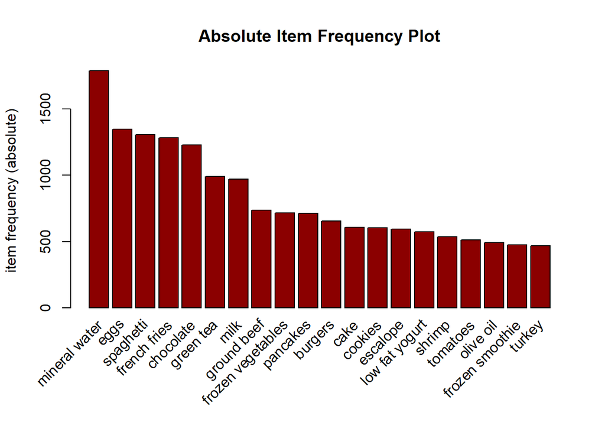

```r
#Displaying top 20 most common items

itemFrequencyPlot(df,topN=20,type="absolute",col="darkred", main="Absolute Item Frequency Plot")
```

- Mineral water has the most sales followed by eggs and so on. To immprove the sale of tomatoes, the retailer can place it near ground beef.

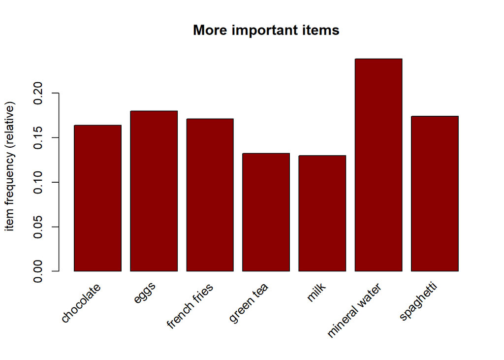

```r
#items whose relative importance is above 10%
itemFrequencyPlot(df, support = 0.1,col="darkred", main='More important items')
```

##4.GENERATING RULES##

Next step is to mine the rules using the APRIORI algorithm. The function apriori() is from package arules.

- We will use Min Support as 0.001, confidence as 0.8.

```r
association_rules <- apriori(df, parameter = list(supp=0.001, conf=0.8))
```

```
## Apriori
##
## Parameter specification:
##  confidence minval smax arem  aval originalSupport maxtime support minlen
##         0.8    0.1    1 none FALSE            TRUE       5   0.001      1
##  maxlen target  ext
##      10  rules TRUE
##
## Algorithmic control:
##  filter tree heap memopt load sort verbose
##     0.1 TRUE TRUE  FALSE TRUE    2    TRUE
##
## Absolute minimum support count: 7
##
## set item appearances ...[0 item(s)] done [0.00s].
## set transactions ...[119 item(s), 7501 transaction(s)] done [0.00s].
## sorting and recoding items ... [116 item(s)] done [0.00s].
## creating transaction tree ... done [0.00s].
## checking subsets of size 1 2 3 4 5 6 done [0.00s].
## writing ... [74 rule(s)] done [0.01s].
## creating S4 object  ... done [0.00s].
```

- 74 rules generated

```r
summary(association_rules)
```

```
## set of 74 rules
##
## rule length distribution (lhs + rhs):sizes
##  3  4  5  6
## 15 42 16  1
##
##    Min. 1st Qu.  Median    Mean 3rd Qu.    Max.
##   3.000   4.000   4.000   4.041   4.000   6.000
##
## summary of quality measures:
##     support           confidence        coverage             lift
##  Min.   :0.001067   Min.   :0.8000   Min.   :0.001067   Min.   : 3.356
##  1st Qu.:0.001067   1st Qu.:0.8000   1st Qu.:0.001333   1st Qu.: 3.432
##  Median :0.001133   Median :0.8333   Median :0.001333   Median : 3.795
##  Mean   :0.001256   Mean   :0.8504   Mean   :0.001479   Mean   : 4.823
##  3rd Qu.:0.001333   3rd Qu.:0.8889   3rd Qu.:0.001600   3rd Qu.: 4.877
##  Max.   :0.002533   Max.   :1.0000   Max.   :0.002666   Max.   :12.722
##      count
##  Min.   : 8.000
##  1st Qu.: 8.000
##  Median : 8.500
##  Mean   : 9.419
##  3rd Qu.:10.000
##  Max.   :19.000
##
## mining info:
##  data ntransactions support confidence
##    df          7501   0.001        0.8
##                                                            call
##  apriori(data = df, parameter = list(supp = 0.001, conf = 0.8))
```

```r
#print top 5 rules
inspect(association_rules[1:5])
```

```
##     lhs                              rhs             support     confidence
## [1] {frozen smoothie, spinach}    => {mineral water} 0.001066524 0.8888889
## [2] {bacon, pancakes}             => {spaghetti}     0.001733102 0.8125000
## [3] {nonfat milk, turkey}         => {mineral water} 0.001199840 0.8181818
## [4] {ground beef, nonfat milk}    => {mineral water} 0.001599787 0.8571429
## [5] {mushroom cream sauce, pasta} => {escalope}      0.002532996 0.9500000
##     coverage    lift      count
## [1] 0.001199840  3.729058  8
## [2] 0.002133049  4.666587 13
## [3] 0.001466471  3.432428  9
## [4] 0.001866418  3.595877 12
## [5] 0.002666311 11.976387 19
```

- 88.9% of the customers who bought ‘frozen smoothie, spinach’ also bought ‘mineral water’.
- 81.2% of the customers who bought ‘bacon, pancakes’ also bought spaghetti

##Redundant rules##

We will remove rules that are subsets of larger rules.

```r
subset_rules <- which(colSums(is.subset(association_rules, association_rules)) > 1) # get subset rules in vector
length(subset_rules)
```

```
## [1] 12
```

- There are 12 redundant rules

Now remove the subset rules

```r
subset.association_rules. <- association_rules[-subset_rules]
```

##Rules related to given items##

- We will use *appearance* option in the apriori command. appearance gives us options to set *LHS* (IF part) and *RHS* (THEN part) of the rule.

*Find what customers buy before buying mineral water*

```r
mineral_water <- apriori(df, parameter = list(supp=0.001, conf=0.8),appearance = list(default="lhs",rhs="mineral water"))
```

```
## Apriori
##
## Parameter specification:
##  confidence minval smax arem  aval originalSupport maxtime support minlen
##         0.8    0.1    1 none FALSE            TRUE       5   0.001      1
##  maxlen target  ext
##      10  rules TRUE
##
## Algorithmic control:
##  filter tree heap memopt load sort verbose
##     0.1 TRUE TRUE  FALSE TRUE    2    TRUE
##
## Absolute minimum support count: 7
##
## set item appearances ...[1 item(s)] done [0.00s].
## set transactions ...[119 item(s), 7501 transaction(s)] done [0.00s].
## sorting and recoding items ... [116 item(s)] done [0.00s].
## creating transaction tree ... done [0.01s].
## checking subsets of size 1 2 3 4 5 6 done [0.00s].
## writing ... [41 rule(s)] done [0.00s].
## creating S4 object  ... done [0.00s].
```

```r
inspect(mineral_water[1:5])
```

```
##     lhs                             rhs             support     confidence
## [1] {frozen smoothie, spinach}   => {mineral water} 0.001066524 0.8888889
## [2] {nonfat milk, turkey}        => {mineral water} 0.001199840 0.8181818
## [3] {ground beef, nonfat milk}   => {mineral water} 0.001599787 0.8571429
## [4] {cooking oil, fromage blanc} => {mineral water} 0.001199840 0.8181818
## [5] {black tea, salmon}          => {mineral water} 0.001066524 0.8000000
##     coverage    lift     count
## [1] 0.001199840 3.729058  8
## [2] 0.001466471 3.432428  9
## [3] 0.001866418 3.595877 12
## [4] 0.001466471 3.432428  9
## [5] 0.001333156 3.356152  8
```

```r
mineral_water <- apriori(df, parameter = list(supp=0.001, conf=0.8),appearance = list(lhs="mineral water",default="rhs"))
```

```
## Apriori
##
## Parameter specification:
##  confidence minval smax arem  aval originalSupport maxtime support minlen
##         0.8    0.1    1 none FALSE            TRUE       5   0.001      1
##  maxlen target  ext
##      10  rules TRUE
##
## Algorithmic control:
##  filter tree heap memopt load sort verbose
##     0.1 TRUE TRUE  FALSE TRUE    2    TRUE
##
## Absolute minimum support count: 7
##
## set item appearances ...[1 item(s)] done [0.00s].
## set transactions ...[119 item(s), 7501 transaction(s)] done [0.00s].
## sorting and recoding items ... [116 item(s)] done [0.00s].
## creating transaction tree ... done [0.00s].
## checking subsets of size 1 2 done [0.00s].
## writing ... [0 rule(s)] done [0.00s].
## creating S4 object  ... done [0.00s].
```

```r
inspect(head(mineral_water))
```

##Visualizing Association Rules##

##Scatter Plot##

```
## To reduce overplotting, jitter is added! Use jitter = 0 to prevent jitter.
```

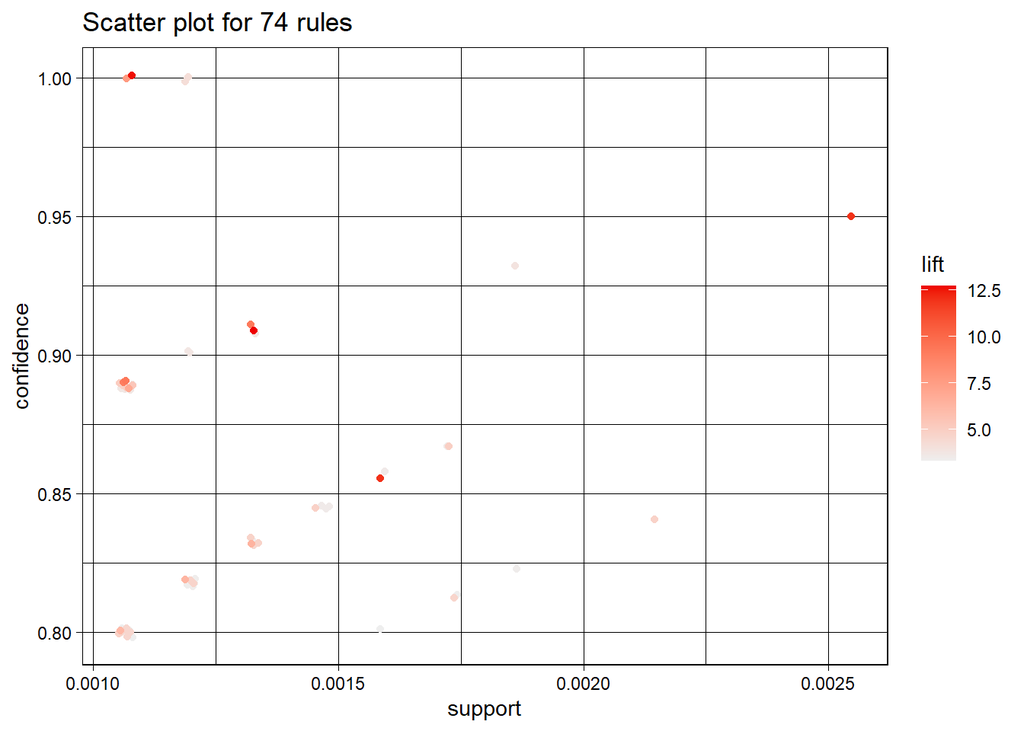

```r
# Filter rules with confidence greater than 0.6 or 60%
subRules<-association_rules[quality(association_rules)$confidence>0.6]
#Plot SubRules
plot(subRules)
```

##The two-key plot##

- The two-key plot uses support and confidence on x and y-axis respectively. It uses order for coloring.

```
## To reduce overplotting, jitter is added! Use jitter = 0 to prevent jitter.
```

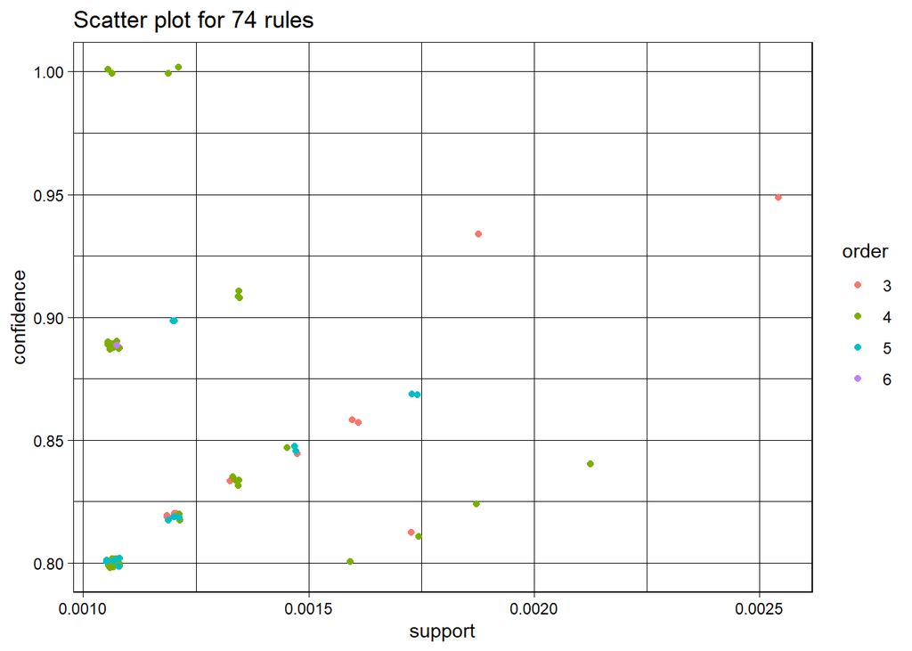

```r
plot(subRules,method="two-key plot")
```

- The order is the number of items in the rule

##Interactive Plot##

```r
top10subRules <- head(subRules, n = 10, by = "confidence")
plot(top10subRules, method = "graph",  engine = "htmlwidget")
```

[interactive chart not shown]

##5. CONCLUSION##

Items transacted by customers has a relationship

##6. RECOMMENDATION##

Products that are popular among customers, those that are most likely to entice them such as mineral water should be placed at the eye level